# Problem Set 2

Brian Gilmore

2023-02-09

[1]

```r
#Q1 Code
library(pacman)
pacman::p_load(Ecdat, magrittr, dplyr, here, ggplot2, fixest)

ps2_df <- read.csv("ps2-data.csv")
nrow(ps2_df) == 7500
```

```
## [1] TRUE
```

[2]

```r
#Q2 Code
non_black <- ps2_df[ps2_df$i_black == 0, ]
black <- ps2_df[ps2_df$i_black == 1, ]

mean_black_income <- mean(black$income)
mean_nonblack_income <- mean(non_black$income)
mean_black_education <- mean(black$yrs_education)
mean_nonblack_education <- mean(non_black$yrs_education)

mean_black_education
```

```
## [1] 14.4022
```

```r
mean_nonblack_education
```

```
## [1] 14.02774
```

```r
mean_black_income
```

```
## [1] 67806.06
```

```r
mean_nonblack_income
```

```
## [1] 79569.21
```

[3]

```r
#Q3 Code

inc_model <- lm(income ~ i_black, ps2_df)
summary(inc_model)
```

```
##
## Call:
## lm(formula = income ~ i_black, data = ps2_df)
##
## Residuals:
##    Min     1Q Median     3Q    Max
## -86369 -55569 -28569  20431 726431
##
## Coefficients:
##             Estimate Std. Error t value Pr(>|t|)
## (Intercept)    79569       1168  68.096   <2e-16 ***
## i_black       -11763       5311  -2.215   0.0268 *
## ---
## Signif. codes:  0 '***' 0.001 '**' 0.01 '*' 0.05 '.' 0.1 ' ' 1
##
## Residual standard error: 98710 on 7498 degrees of freedom
## Multiple R-squared:  0.0006538,  Adjusted R-squared:  0.0005205
## F-statistic: 4.905 on 1 and 7498 DF,  p-value: 0.02681
```

The intercept is statistically different from 0, and tells us that we can expect a non-black individual to earn about 79569. The coefficient on i_black is also statistically different from 0 and it tells us that a black individual will earn 11763 less than someone who isn’t black. The difference is statistically significant since the p-value is less than .05, indicating the average difference in income when i_black == 1 is -11763. This average difference is also consistent with what we found in question 2, as 67806.06 - 79569.21 is also equivalent to -11763.

[04]

```r
#Q4 Code
ed_model <- lm(yrs_education ~ i_black, ps2_df)
summary(ed_model)
```

```
##
## Call:
## lm(formula = yrs_education ~ i_black, data = ps2_df)
##
## Residuals:
##      Min       1Q   Median       3Q      Max
## -14.4022  -2.0277  -0.0277   1.9723   6.9723
##
## Coefficients:
##             Estimate Std. Error t value Pr(>|t|)
## (Intercept) 14.02774    0.04635 302.640   <2e-16 ***
## i_black      0.37446    0.21069   1.777   0.0756 .
## ---
## Signif. codes:  0 '***' 0.001 '**' 0.01 '*' 0.05 '.' 0.1 ' ' 1
##
## Residual standard error: 3.916 on 7498 degrees of freedom
## Multiple R-squared:  0.0004211,  Adjusted R-squared:  0.0002878
## F-statistic: 3.159 on 1 and 7498 DF,  p-value: 0.07555
```

The intercept is statistically different from 0 and it tells us that we can expect an individual who isn’t black to have 14.02 years of education. The coefficient of i_black is not statistically significant as the p-value exceeds .05, at .07555. However, the effect on yrs_education does match our findings in question 2 as 14.4022 - 14.02774 is equivalent to 0.37446. This would indicate that a black individual to have 14.39 years of education approximately.

[5]

```r
#Q5 Code
model_ba <- lm(yrs_education ~ i_black + age, ps2_df)
summary(model_ba)
```

```
##
## Call:
## lm(formula = yrs_education ~ i_black + age, data = ps2_df)
##
## Residuals:
##      Min       1Q   Median       3Q      Max
## -14.6251  -1.9959   0.1689   2.2238   7.3886
##
## Coefficients:
##              Estimate Std. Error t value Pr(>|t|)
## (Intercept) 16.357636   0.411402  39.761  < 2e-16 ***
## i_black      0.354574   0.210275   1.686   0.0918 .
## age         -0.054924   0.009637  -5.699 1.25e-08 ***
## ---
## Signif. codes:  0 '***' 0.001 '**' 0.01 '*' 0.05 '.' 0.1 ' ' 1
##
## Residual standard error: 3.908 on 7497 degrees of freedom
## Multiple R-squared:  0.004733,   Adjusted R-squared:  0.004468
## F-statistic: 17.83 on 2 and 7497 DF,  p-value: 1.887e-08
```

The intercept and age coefficient is statistically different from 0, however, i_black’s coefficient is not. The intercept tells us that we can expect a non-black individual to have an average of about 16.36 years of education. The coefficient on i_black indicates that a black individual will have about 0.35 more years of education than someone who isn’t black. The coefficient on age tells us that we can expect years of education to decrease about -0.055 with every per unit increase of age. The regression is statistically significant at the 5% level.

[6]

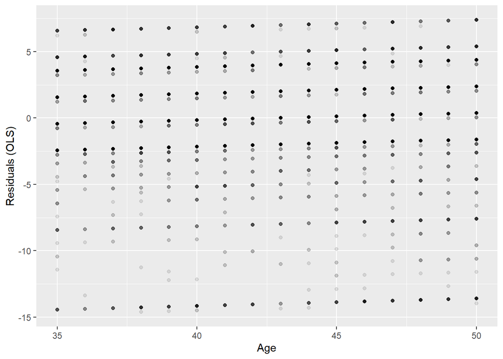

```r
#Q6 Code
ps2_df %<>% mutate(resid1 = resid(model_ba))

ggplot(data = ps2_df, aes(x = age, y = resid1)) +
  geom_point(alpha = .1) +
  labs(x = "Age", y = "Residuals (OLS)")
```

[7] There appears to be some non-constant variance, however it is unclear from the plot.

[8]

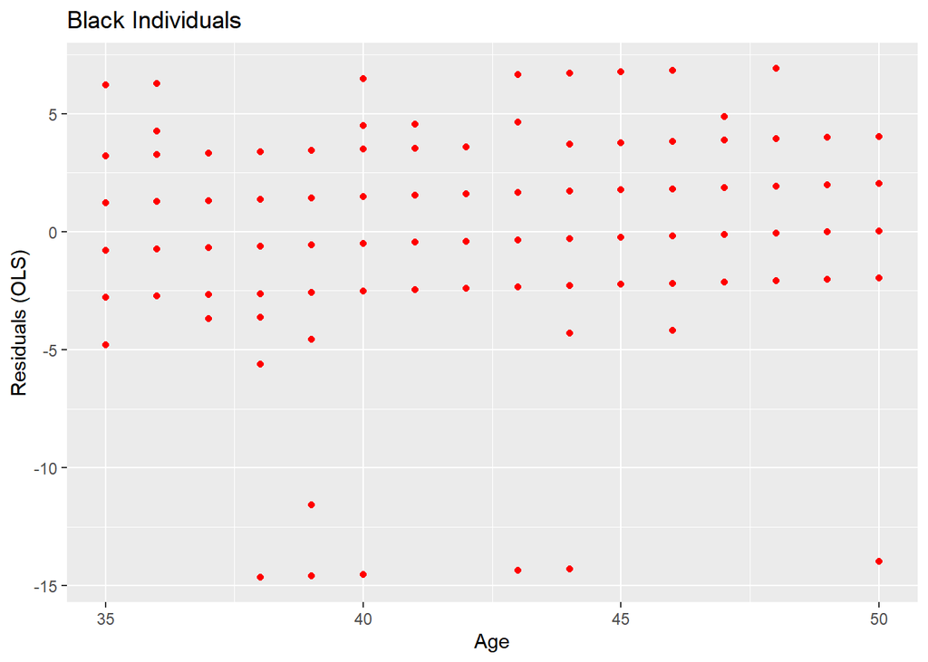

```r
#Q8 Code

ggplot(data = ps2_df, aes(x = age, y = resid1)) +
  labs(x = "Age", y = "Residuals (OLS)") +
  ggtitle("Black Individuals") +
  scale_color_discrete(name = "Black") +
  geom_point(data = subset(ps2_df, i_black == 1), color = "red")
```

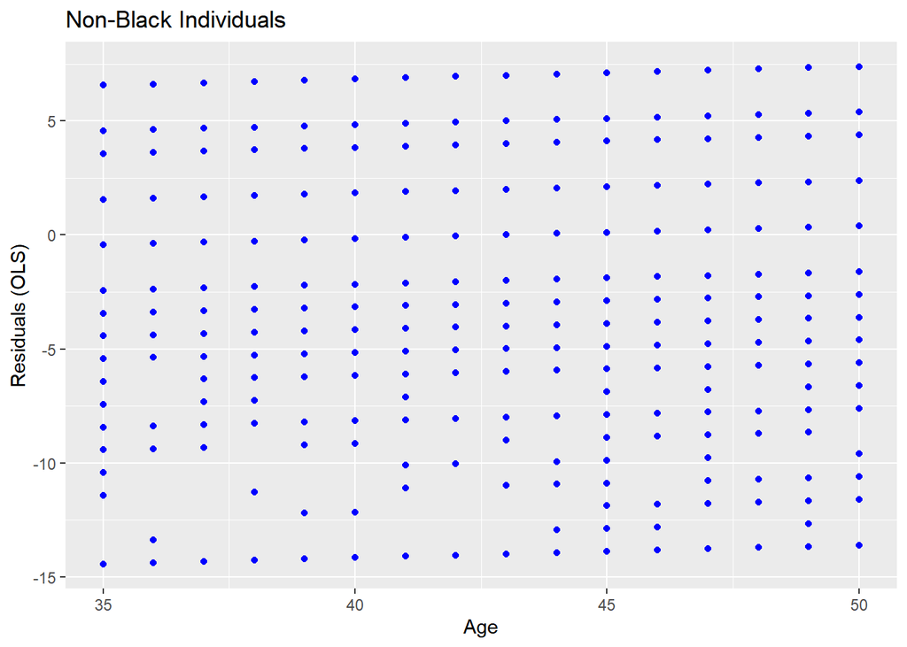

```r
ggplot(data = ps2_df, aes(x = age, y = resid1)) +
  labs(x = "Age", y = "Residuals (OLS)") +
  ggtitle("Non-Black Individuals") +
  scale_color_discrete(name = "Black") +
  geom_point(data = subset(ps2_df, i_black == 0), color = "blue")
```

[9] Heteroskedasticity violates the assumption of constant variance in OLS regression. With this violation, our disturbances will have different variances, changing with each explanatory variable we add. However while our estimates of coefficients are still unbiased, OLS standard errors are now biased in the presence of heteroskedasticity. This results in wrong confidence intervals, problems for hypothesis testing, and making it challenging to learn much about our sample without sound inference.

[10] First we order our observations by variable of interest:

```r
#Q10 Code
ps2_df %<>% arrange(age)
head(ps2_df)
```

|  | income | age | i_female | i_born_usa | i_employed | i_amin | i_asian | i_black | i_white | i_hispanic | yrs_education | resid1 |
| --- | --- | --- | --- | --- | --- | --- | --- | --- | --- | --- | --- | --- |
| 1 | 100000 | 35 | 1 | 0 | 1 | 0 | 0 | 0 | 1 | 1 | 16 | 1.5647216 |
| 2 | 2000 | 35 | 1 | 0 | 1 | 0 | 0 | 0 | 0 | 1 | 6 | -8.4352784 |
| 3 | 58000 | 35 | 1 | 1 | 1 | 0 | 0 | 0 | 1 | 1 | 16 | 1.5647216 |
| 4 | 170000 | 35 | 1 | 1 | 1 | 0 | 1 | 0 | 0 | 0 | 18 | 3.5647216 |
| 5 | 16300 | 35 | 0 | 1 | 1 | 0 | 0 | 0 | 1 | 0 | 14 | -0.4352784 |
| 6 | 58000 | 35 | 1 | 1 | 1 | 0 | 0 | 0 | 1 | 0 | 14 | -0.4352784 |

Then we split our data into 2 groups:

```r
#Q10 Code
(n_GQ = as.integer((3/8)*nrow(ps2_df)))
```

```
## [1] 2812
```

Then we run separate regressions on yrs_education with the indicator i_black and age:

```r
#Q10 Code

# First for higher ages

mod_g1 = lm(
  data = tail(ps2_df, n = n_GQ),
  yrs_education ~ i_black + age
)
# Now for lower ages

mod_g2 = lm(
  data = head(ps2_df, n = n_GQ),
  yrs_education ~ i_black + age
)
```

Then we calculate the sum of squared errors:

```r
#Q10 Code

# First getting residuals from both regressions
e_g1 = resid(mod_g1)
e_g2 = resid(mod_g2)
# Then summing their squares
sse_g1 = sum(e_g1 ^ 2)
sse_g2 = sum(e_g2 ^ 2)
```

Then we calculate the GQ Test Stat and its p-value:

```r
#Q10 Code

(stat_GQ = (sse_g2/sse_g1))
```

```
## [1] 0.7496196
```

```r
# Getting the number of coefficients we estimated
k = length(model_ba$coefficients)

# pf gives probability from an f-dist
(p_GQ = pf(
  q = stat_GQ,
  df1 = n_GQ - k,
  df2 = n_GQ - k,
  lower.tail = F
))
```

```
## [1] 1
```

Finally we compare our values and state hypotheses:

H0: The variances of the residuals from regressions using the first 3/8 and the last 3/8 of the dataset ordered by age are the same. σ21=σ22

Ha: The variances of the residuals from regressions using the first 3/8 and the last 3/8 of the dataset ordered by age are different. σ21≠σ22

[11] Goldfeld Quandt requires that disturbances follow normal distributions and it assumes a very specific form of heteroskedasticity from only linear regression models. The results of the test also only indicate whether or not heteroskedasticity is present, without providing much information about the type of heteroskedasticity. Outliers also have a strong effect on the results of the test, which indicates the test is sensitive to extreme residuals. Overall the test performs well if the potential form of heteroskedasticity is known, the distribution of disturbances is normal, and there are minimal outliers in the residuals.

[12] The White test assumes u^2 is uncorrelated with the explanatory variables, their squares, and the first-degree interactions. I include all of my code below in this one block:

```r
#Q12 Code

#First we run our regression
mod_ols <- lm(yrs_education ~ i_black + age, ps2_df)

# Then we take the residuals of the regression
e_white = resid(mod_ols)

# Regressing squared residuals on terms
mod_white = lm(
  data = ps2_df,
  I(e_white^2) ~
    i_black + age + i_black:age + I(age^2)
) #we don't include squared binary variables


# Getting r-squared
(r2_white = summary(mod_white)$r.squared)
```

```
## [1] 0.004414966
```

```r
# Calculate the test stat
stat_white = nrow(ps2_df)* r2_white

# Calculating the p-value from chi-sq distribution
pchisq(q = stat_white, df = 4, lower.tail = F)
```

```
## [1] 1.132913e-06
```

```r
(summary(mod_white))
```

```
##
## Call:
## lm(formula = I(e_white^2) ~ i_black + age + i_black:age + I(age^2),
##     data = ps2_df)
##
## Residuals:
##     Min      1Q  Median      3Q     Max
## -18.866 -13.077 -10.483   0.266 202.391
##
## Coefficients:
##              Estimate Std. Error t value Pr(>|t|)
## (Intercept) -0.094110  38.123935  -0.002    0.998
## i_black     22.246045  17.828670   1.248    0.212
## age          0.277423   1.808725   0.153    0.878
## I(age^2)     0.002096   0.021245   0.099    0.921
## i_black:age -0.637341   0.421393  -1.512    0.130
##
## Residual standard error: 34.96 on 7495 degrees of freedom
## Multiple R-squared:  0.004415,   Adjusted R-squared:  0.003884
## F-statistic: 8.309 on 4 and 7495 DF,  p-value: 1.104e-06
```

With a p-value of 1.132913e-06, we can reject the null hypothesis that says there is homoskedasticity in the residuals. This indicates the variance of the residuals is not constant, and that heteroskedasticity is present in the residuals.

[13] First we take our regression:

```r
#Q13 Code

mod_feols <- feols(yrs_education ~ i_black + age, data = ps2_df, )

# We then examine the usual standard errors
summary(mod_feols)
```

```
## OLS estimation, Dep. Var.: yrs_education
## Observations: 7,500
## Standard-errors: IID
##              Estimate Std. Error  t value   Pr(>|t|)
## (Intercept) 16.357636   0.411402 39.76070  < 2.2e-16 ***
## i_black      0.354574   0.210275  1.68624 9.1792e-02 .
## age         -0.054924   0.009637 -5.69944 1.2476e-08 ***
## ---
## Signif. codes:  0 '***' 0.001 '**' 0.01 '*' 0.05 '.' 0.1 ' ' 1
## RMSE: 3.90681   Adj. R2: 0.004468
```

Now we look at the robust standard errors:

```r
#Q13 Code

# Het-robust standard errors
summary(mod_feols, vcov = "hetero")
```

```
## OLS estimation, Dep. Var.: yrs_education
## Observations: 7,500
## Standard-errors: Heteroskedasticity-robust
##              Estimate Std. Error  t value   Pr(>|t|)
## (Intercept) 16.357636   0.406932 40.19751  < 2.2e-16 ***
## i_black      0.354574   0.178291  1.98874 4.6766e-02 *
## age         -0.054924   0.009680 -5.67418 1.4455e-08 ***
## ---
## Signif. codes:  0 '***' 0.001 '**' 0.01 '*' 0.05 '.' 0.1 ' ' 1
## RMSE: 3.90681   Adj. R2: 0.004468
```

[14] Updating the standard errors to be robust to heteroskedasticity adjusts for the original bias held by standard errors in the previous regression. for i_black. Now our inferences are more accurate about the effect of age and race on yrs_education, and our i_black binary variable is statistically significant with a p-value of 4.6766e-02.

[15] The coefficients remain unbiased, as robust to heteroskedasticity standard errors don’t have an effect on the relationship between independent and dependent variables. The only difference now is that the standard errors are based on a more accurate estimate of the variance of the coefficients.

[16] The drawback to using WLS in this context is that we would need to know the functional form of the heteroskedasticity where σ^2_i =σ^2h(x_i) or σ^2_i. This would give us trouble when trying to apply the appropriate weights to each observation.

[17]

```r
#Q17 Code


# First let's run the original regression
mod_cluster = feols(
  data = ps2_df,
  fml = yrs_education ~ i_black,
  cluster = ~ age
)

# Summary of results
summary(mod_cluster)
```

```
## OLS estimation, Dep. Var.: yrs_education
## Observations: 7,500
## Standard-errors: Clustered (age)
##              Estimate Std. Error   t value  Pr(>|t|)
## (Intercept) 14.027743   0.090903 154.31554 < 2.2e-16 ***
## i_black      0.374461   0.217346   1.72288   0.10546
## ---
## Signif. codes:  0 '***' 0.001 '**' 0.01 '*' 0.05 '.' 0.1 ' ' 1
## RMSE: 3.91527   Adj. R2: 2.878e-4
```

[19] We adjust our standard errors to be robust to clustering to reduce non-zero covariance between any two error terms. For example black individuals belonging to a certain age group may have correlated disturbances in our regression since they experience similar environments and conditions. Clustering aims to remove dependencies of the error term when calculating standard errors in a regression.

[20] Another example of a dimension where our sample could have correlated disturbances is our variable income, where many individual demographics within our sample may have correlated disturbances. For example, it is likely that many females belonging to a certain income level will have correlated disturbances since they may experience similar conditions.